# dl

### UNIVARIATE DEEP LEARNING PREDICTION

Univariate deep learning models are a type of machine learning algorithm that uses a single input variable to predict future values of that variable. In the context of stock market analysis, univariate models can be used to make predictions based on historical data for a particular stock or stock index.

By using univariate deep learning models, such as recurrent neural networks (RNNs), long short-term memory (LSTM) networks, and gated recurrent units (GRUs), analysts can make predictions on the future values of these stock indices based on their historical data. These models are designed to capture complex patterns and trends in the data, which can be used to inform investment strategies and help traders make informed decisions.

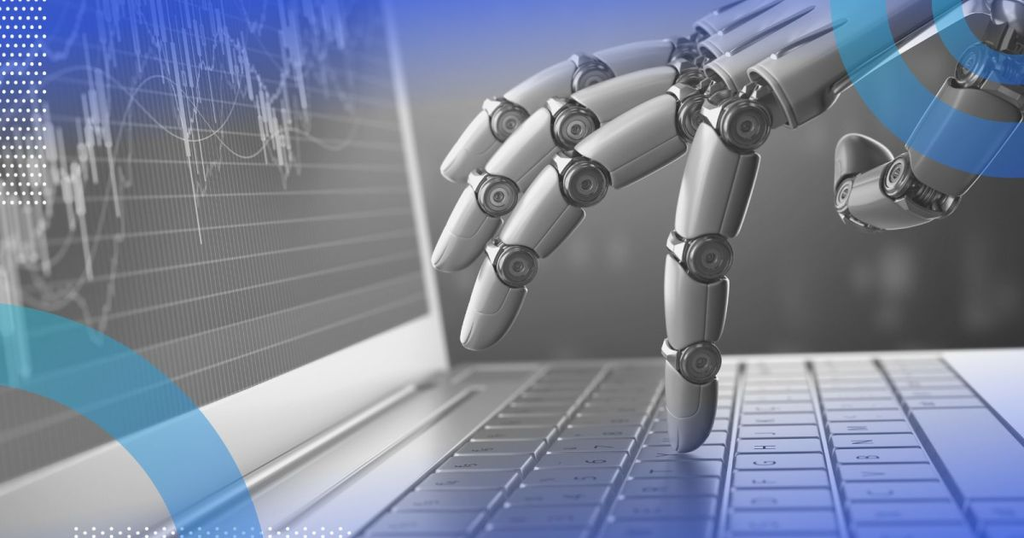

#### UNIVARIATE DEEP LEARNING PREDICTION FOR STOCK INDEX

In this context, we will be looking at the top 3 stock price indexes: S&P 500, Dow Jones Industrial Average (DJIA), and Nasdaq Composite. These indexes are widely used as benchmarks for the overall performance of the US stock market, and predicting their future movements is of great interest to investors, traders, and financial analysts. By using deep learning models, we can leverage the power of neural networks to capture complex patterns and relationships in the historical data, and use them to make more accurate predictions about future movements of these stock price indexes.

#### UNIVARIATE DEEP LEARNING PREDICTION FOR SECTOR MARKET

In this context, we will be looking at the sector market, which is made up of indexes that track the performance of specific industry sectors within the stock market, such as technology, healthcare, and energy. These sector indexes are widely used as indicators of the performance of their respective industries and can provide insights into the overall health of the stock market. By using deep learning models, we can leverage the power of neural networks to capture complex patterns and relationships in the historical data of a specific sector index and use them to make more accurate predictions about future movements of that index. This can be particularly useful for investors, traders, and financial analysts who specialize in a specific industry sector and need to make informed decisions based on its market trends.

Click to view Consumer Staples Sector Fund

Click to view Utilities Sector Fund

Click to view Health Care Sector Fund

Click to view Industrial Sector Fund

Click to view Financial Sector Fund

Click to view Consumer Discretionary Sector Fund

Click to view Communication Services Sector Fund

Click to view Real Estate Sector Fund

Click to view Materials Sector Fund

Click to view Technology Sector Fund

Click to view Energy Sector Fund